# e-Commerce Exploratory Data Analysis (EDA)

Dorcas Mbaeri

March 3, 2018

### Structure of data

This is the introduction to my senior project at the University of Houston-Downtown. We will begin by exploring the dataset containing Zappos.com’s customer transactions.

But first let’s load the data.

```r
mydata <- read.csv("C:/Users/Dorcas/OneDrive - University of Houston Downtown/SeniorProject/Senior Project/Analytics_Challenge_Data.csv", header = TRUE, row.names = NULL, na = "NA")

my_data <- data.table(mydata)
```

Now, let’s take look at the structure of the data and missing values. From the below, we see that there are 8259 blank values in *new_customer* as well as 2469 blank values for *conversion rate*, *bounce_rate*, *add_to_cart_rate*. Note that the last three columns are calculated using *orders*, *bounces*, *add_to_cart*, and *visits*. Conversion rate is calculted by diving the number of orders by visits; bounce rate is calculated by dividing bounces by visits; and, add to cart rate is dividing add to cart by visits. So, if there is a division by 0 (meaning with 0 visits), this woud be *null*.

```r
summary(mydata)
```

```
##               day              site       new_customer      platform
##  12/19/2013 0:00:   86   Acme    :7392   Min.   :0.000   iOS    :3435
##  11/29/2013 0:00:   85   Botly   : 804   1st Qu.:0.000   Android:3172
##  12/11/2013 0:00:   85   Pinnacle:5725   Median :0.000   Windows:2399
##  12/7/2013 0:00 :   85   Sortly  :5532   Mean   :0.448   MacOSX :2054
##  12/2/2013 0:00 :   84   Tabular : 804   3rd Qu.:1.000   Linux  :2036
##  12/5/2013 0:00 :   84   Widgetry: 804   Max.   :1.000   Unknown:1641
##  (Other)        :20552                   NA's   :8259    (Other):6324
##      visits       distinct_sessions     orders         gross_sales
##  Min.   :     0   Min.   :     0    Min.   :   0.00   Min.   :     1
##  1st Qu.:     3   1st Qu.:     2    1st Qu.:   0.00   1st Qu.:    79
##  Median :    24   Median :    19    Median :   0.00   Median :   851
##  Mean   :  1935   Mean   :  1515    Mean   :  62.38   Mean   : 16473
##  3rd Qu.:   360   3rd Qu.:   274    3rd Qu.:   7.00   3rd Qu.:  3145
##  Max.   :136057   Max.   :107104    Max.   :4916.00   Max.   :707642
##                                                       NA's   :9576
##     bounces         add_to_cart     product_page_views search_page_views
##  Min.   :    0.0   Min.   :   0.0   Min.   :     0     Min.   :     0
##  1st Qu.:    0.0   1st Qu.:   0.0   1st Qu.:     3     1st Qu.:     4
##  Median :    5.0   Median :   4.0   Median :    53     Median :    82
##  Mean   :  743.3   Mean   : 166.3   Mean   :  4358     Mean   :  8584
##  3rd Qu.:   97.0   3rd Qu.:  43.0   3rd Qu.:   708     3rd Qu.:  1229
##  Max.   :54512.0   Max.   :7924.0   Max.   :187601     Max.   :506629
##
##  conversion_rate   bounce_rate     add_to_cart_rate
##  Min.   :0.0000   Min.   :0.0000   Min.   :0.0000
##  1st Qu.:0.0000   1st Qu.:0.1429   1st Qu.:0.0223
##  Median :0.0000   Median :0.3118   Median :0.1667
##  Mean   :0.2201   Mean   :0.3396   Mean   :0.2935
##  3rd Qu.:0.3571   3rd Qu.:0.5024   3rd Qu.:0.5000
##  Max.   :1.0000   Max.   :1.0000   Max.   :1.0000
##  NA's   :2469     NA's   :2469     NA's   :2469
```

```r
dim(mydata)
```

```
## [1] 21061    15
```

```r
str(mydata)
```

```
## 'data.frame':    21061 obs. of  15 variables:
##  $ day               : Factor w/ 268 levels "1/1/2013 0:00",..: 1 1 1 1 1 1 1 1 1 1 ...
##  $ site              : Factor w/ 6 levels "Acme","Botly",..: 1 1 4 1 2 1 4 4 1 1 ...
##  $ new_customer      : int  1 1 1 1 1 1 1 1 0 0 ...
##  $ platform          : Factor w/ 15 levels "","Android","BlackBerry",..: 2 3 6 14 2 9 2 14 8 7 ...
##  $ visits            : int  24 0 0 922 11 384 14 1 41 448 ...
##  $ distinct_sessions : int  16 0 0 520 10 214 10 0 27 368 ...
##  $ orders            : int  14 0 0 527 11 213 4 0 6 36 ...
##  $ gross_sales       : int  1287 13 98 60753 1090 28129 432 31 705 4637 ...
##  $ bounces           : int  4 0 0 149 0 65 4 0 6 80 ...
##  $ add_to_cart       : int  16 0 0 610 11 245 7 0 12 79 ...
##  $ product_page_views: int  104 1 0 3914 4 1783 33 2 130 722 ...
##  $ search_page_views : int  192 0 0 7367 19 3255 52 2 272 1073 ...
##  $ conversion_rate   : num  0.583 NA NA 0.572 1 ...
##  $ bounce_rate       : num  0.167 NA NA 0.162 0 ...
##  $ add_to_cart_rate  : num  0.667 NA NA 0.662 1 ...
```

```r
head(mydata)
```

```
##             day   site new_customer   platform visits distinct_sessions
## 1 1/1/2013 0:00   Acme            1    Android     24                16
## 2 1/1/2013 0:00   Acme            1 BlackBerry      0                 0
## 3 1/1/2013 0:00 Sortly            1       iPad      0                 0
## 4 1/1/2013 0:00   Acme            1    Windows    922               520
## 5 1/1/2013 0:00  Botly            1    Android     11                10
## 6 1/1/2013 0:00   Acme            1  Macintosh    384               214
##   orders gross_sales bounces add_to_cart product_page_views
## 1     14        1287       4          16                104
## 2      0          13       0           0                  1
## 3      0          98       0           0                  0
## 4    527       60753     149         610               3914
## 5     11        1090       0          11                  4
## 6    213       28129      65         245               1783
##   search_page_views conversion_rate bounce_rate add_to_cart_rate
## 1               192       0.5833333   0.1666667        0.6666667
## 2                 0              NA          NA               NA
## 3                 0              NA          NA               NA
## 4              7367       0.5715835   0.1616052        0.6616052
## 5                19       1.0000000   0.0000000        1.0000000
## 6              3255       0.5546875   0.1692708        0.6380208
```

```r
colSums(sapply(mydata, is.na))
```

```
##                day               site       new_customer
##                  0                  0               8259
##           platform             visits  distinct_sessions
##                  0                  0                  0
##             orders        gross_sales            bounces
##                  0               9576                  0
##        add_to_cart product_page_views  search_page_views
##                  0                  0                  0
##    conversion_rate        bounce_rate   add_to_cart_rate
##               2469               2469               2469
```

We want to identify the number of missing values in each numeric column.

```r
num_var <- names(my_data)[which(sapply(my_data, is.numeric))]

summary(my_data[,.SD, .SDcols = num_var])
```

```
##   new_customer       visits       distinct_sessions     orders
##  Min.   :0.000   Min.   :     0   Min.   :     0    Min.   :   0.00
##  1st Qu.:0.000   1st Qu.:     3   1st Qu.:     2    1st Qu.:   0.00
##  Median :0.000   Median :    24   Median :    19    Median :   0.00
##  Mean   :0.448   Mean   :  1935   Mean   :  1515    Mean   :  62.38
##  3rd Qu.:1.000   3rd Qu.:   360   3rd Qu.:   274    3rd Qu.:   7.00
##  Max.   :1.000   Max.   :136057   Max.   :107104    Max.   :4916.00
##  NA's   :8259
##   gross_sales        bounces         add_to_cart     product_page_views
##  Min.   :     1   Min.   :    0.0   Min.   :   0.0   Min.   :     0
##  1st Qu.:    79   1st Qu.:    0.0   1st Qu.:   0.0   1st Qu.:     3
##  Median :   851   Median :    5.0   Median :   4.0   Median :    53
##  Mean   : 16473   Mean   :  743.3   Mean   : 166.3   Mean   :  4358
##  3rd Qu.:  3145   3rd Qu.:   97.0   3rd Qu.:  43.0   3rd Qu.:   708
##  Max.   :707642   Max.   :54512.0   Max.   :7924.0   Max.   :187601
##  NA's   :9576
##  search_page_views conversion_rate   bounce_rate     add_to_cart_rate
##  Min.   :     0    Min.   :0.0000   Min.   :0.0000   Min.   :0.0000
##  1st Qu.:     4    1st Qu.:0.0000   1st Qu.:0.1429   1st Qu.:0.0223
##  Median :    82    Median :0.0000   Median :0.3118   Median :0.1667
##  Mean   :  8584    Mean   :0.2201   Mean   :0.3396   Mean   :0.2935
##  3rd Qu.:  1229    3rd Qu.:0.3571   3rd Qu.:0.5024   3rd Qu.:0.5000
##  Max.   :506629    Max.   :1.0000   Max.   :1.0000   Max.   :1.0000
##                    NA's   :2469     NA's   :2469     NA's   :2469
```

```r
colSums(sapply(my_data[,.SD, .SDcol = num_var], is.na))
```

```
##       new_customer             visits  distinct_sessions
##               8259                  0                  0
##             orders        gross_sales            bounces
##                  0               9576                  0
##        add_to_cart product_page_views  search_page_views
##                  0                  0                  0
##    conversion_rate        bounce_rate   add_to_cart_rate
##               2469               2469               2469
```

The summary statistics helps to see the distribution of the numerical variables. For example, the mean number of *visits* in the data is **1935**, the median is **24**, and the maximum value is **136057**. In this scenario, we can conclude that the spread of this dimension is *skewed right* or positively skewed (with the mean to the right of the median). We will test some of these columns using a boxplot to visualize their spread.

Let’s also do a comparison of missing values in the categorical columns.

```r
char_var <- names(my_data)[which(sapply(my_data, is.factor))]

summary(my_data[,.SD, .SDcols = char_var])
```

```
##               day              site         platform
##  12/19/2013 0:00:   86   Acme    :7392   iOS    :3435
##  11/29/2013 0:00:   85   Botly   : 804   Android:3172
##  12/11/2013 0:00:   85   Pinnacle:5725   Windows:2399
##  12/7/2013 0:00 :   85   Sortly  :5532   MacOSX :2054
##  12/2/2013 0:00 :   84   Tabular : 804   Linux  :2036
##  12/5/2013 0:00 :   84   Widgetry: 804   Unknown:1641
##  (Other)        :20552                   (Other):6324
```

```r
colSums(sapply(my_data[,.SD, .SDcols = char_var], is.na))
```

```
##      day     site platform
##        0        0        0
```

It’s always a lot easier when we can visualize any missing data representation. So we will create a function that will visually display the comparison of missing values to non-missing values in our data set. *(kaggle post by AiO)*

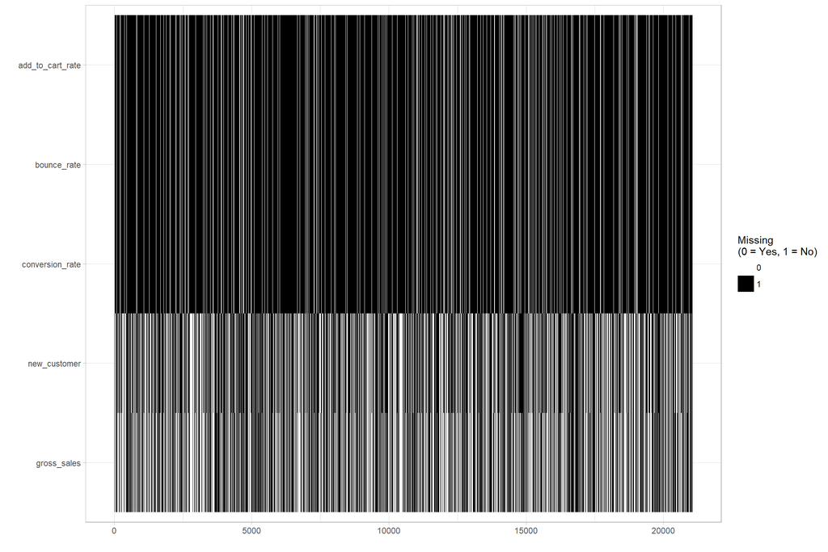

```r
Missing_Values <- function(input_data) {
  temp_data <- as.data.frame(ifelse(is.na(input_data), 0, 1))
  temp_data <- temp_data[, order(colSums(temp_data))]
  data_temp <- expand.grid(list(x= 1:nrow(temp_data), y=colnames(temp_data)))
  data_temp$m <- as.vector(as.matrix(temp_data))
  data_temp <- data.frame(x = unlist(data_temp$x), y = unlist(data_temp$y), m = unlist(data_temp$m))

  ggplot(data_temp) +
    geom_tile(aes(x=x, y=y, fill=factor(m))) +
    scale_fill_manual(values=c("white", "black"), name = "Missing\n(0 = Yes, 1 = No)") +
    theme_light() +
    ylab("") +
    xlab("")
}

Missing_Values(my_data[, colSums(is.na(my_data)) > 0, with = FALSE])
```

Here are visual distributions of the categorical variables of *mydata* (excludes missing values):

Distribution of *site*

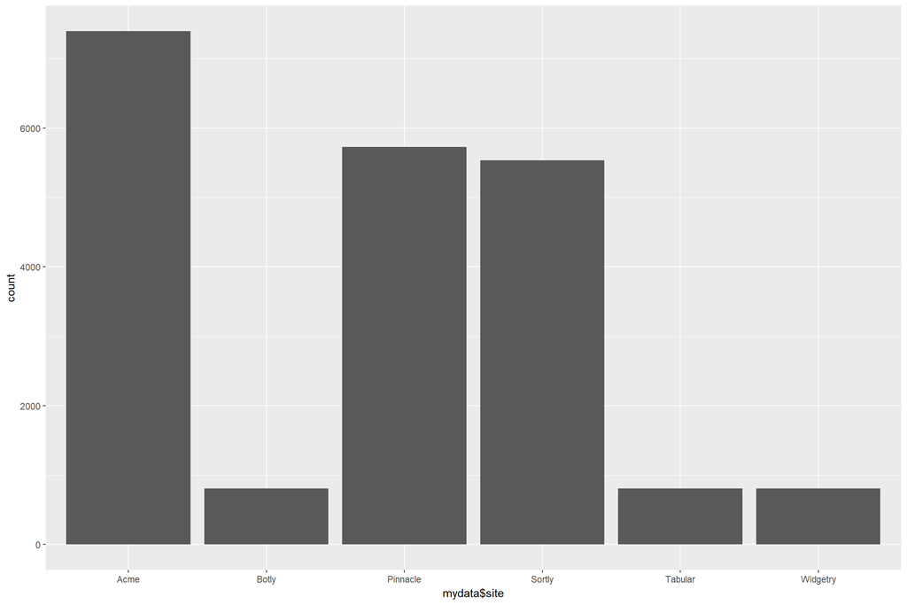

```r
ggplot(data = mydata) +
  geom_bar(mapping = aes(x = mydata$site), na.rm = TRUE)
```

*new_customer* distribution

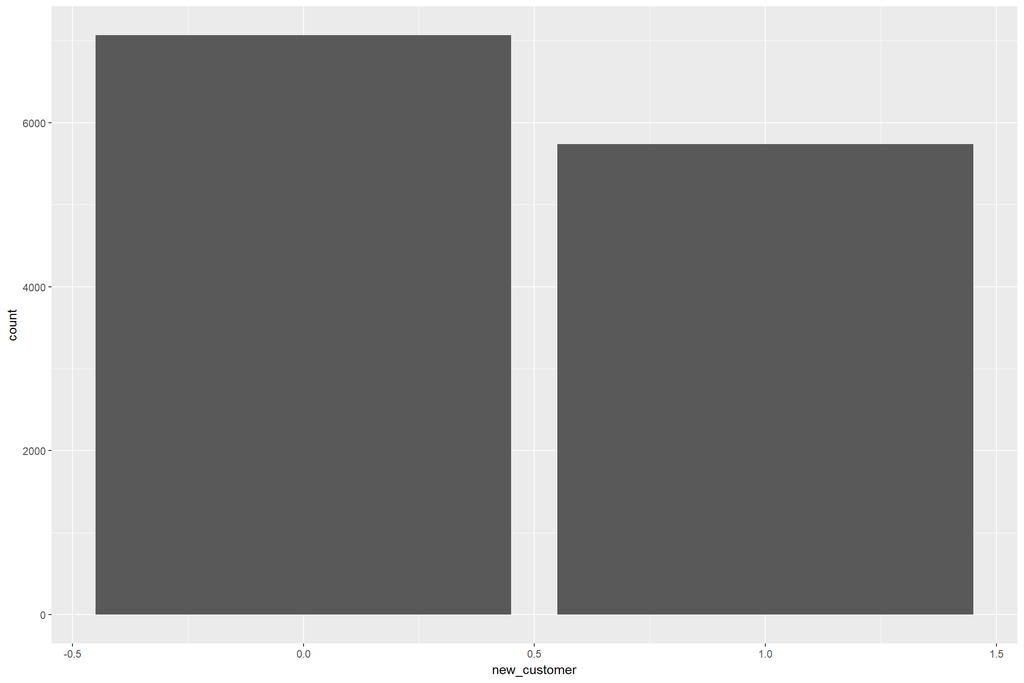

```r
ggplot(data=mydata) +
  geom_bar(mapping = aes(x = new_customer), na.rm = TRUE)
```

*platform* distribution

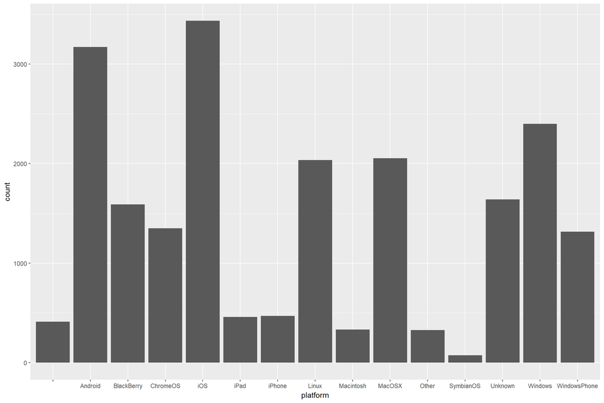

```r
ggplot(data = mydata, mapping = aes(x = platform), na.ra = TRUE) +
  geom_histogram(stat = "count", position = position_stack(reverse = TRUE), na.ra = TRUE)
```

We can take a look at the distribution of *conversion_rate*, *bounce_rate* and *add_to_cart_rate* by *new_customer* as boxplots and frequency plots. From these plots, we see that Acme and Android and iOS are the most most used site and platforms to have items searched for as well as added to cart.

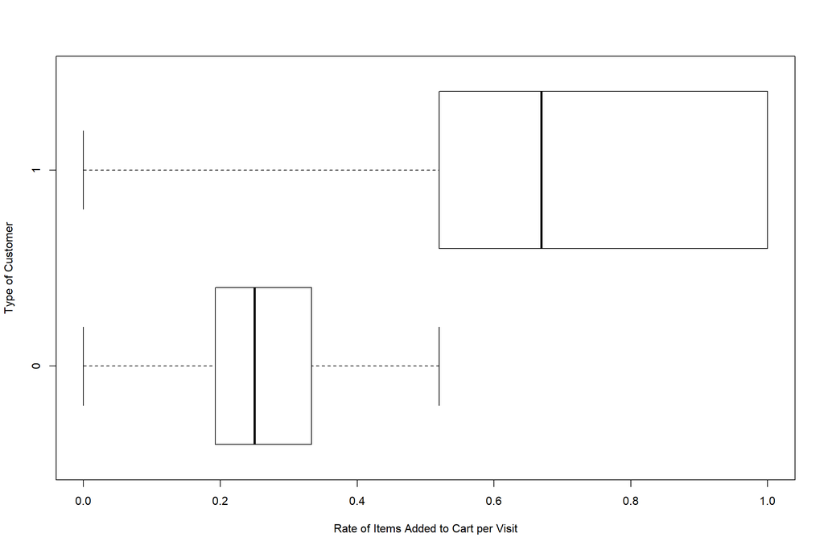

```r
boxplot(mydata$add_to_cart_rate ~ mydata$new_customer, outline=FALSE, xlab = 'Rate of Items Added to Cart per Visit', ylab='Type of Customer', horizontal=TRUE)
```

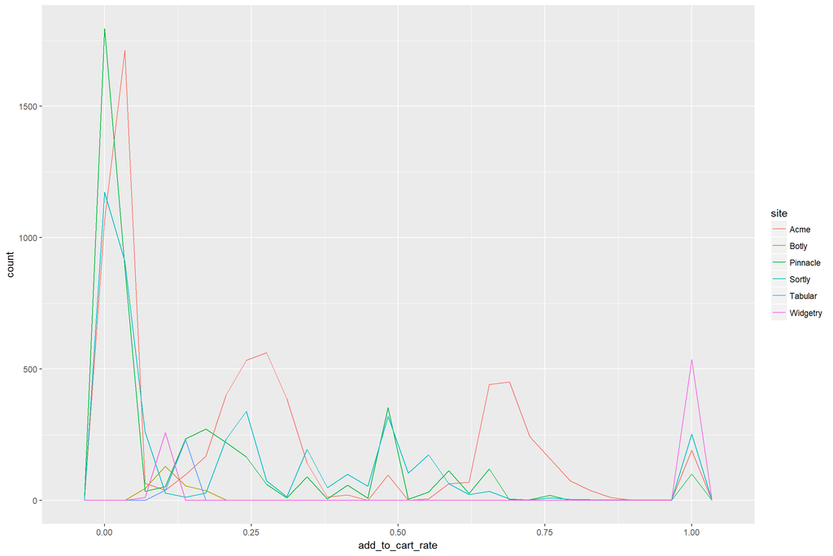

```r
ggplot(data=mydata, mapping = aes(x = add_to_cart_rate)) +
  geom_freqpoly(mapping = aes(color = site))
```

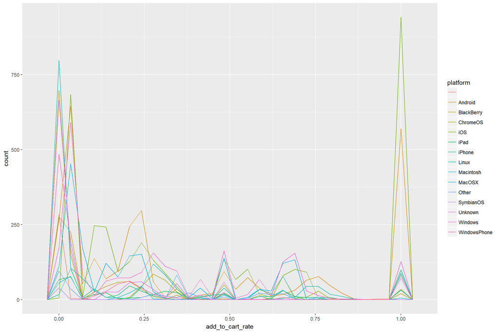

```r
ggplot(data=mydata, mapping = aes(x = add_to_cart_rate)) +
  geom_freqpoly(mapping = aes(color = platform))
```

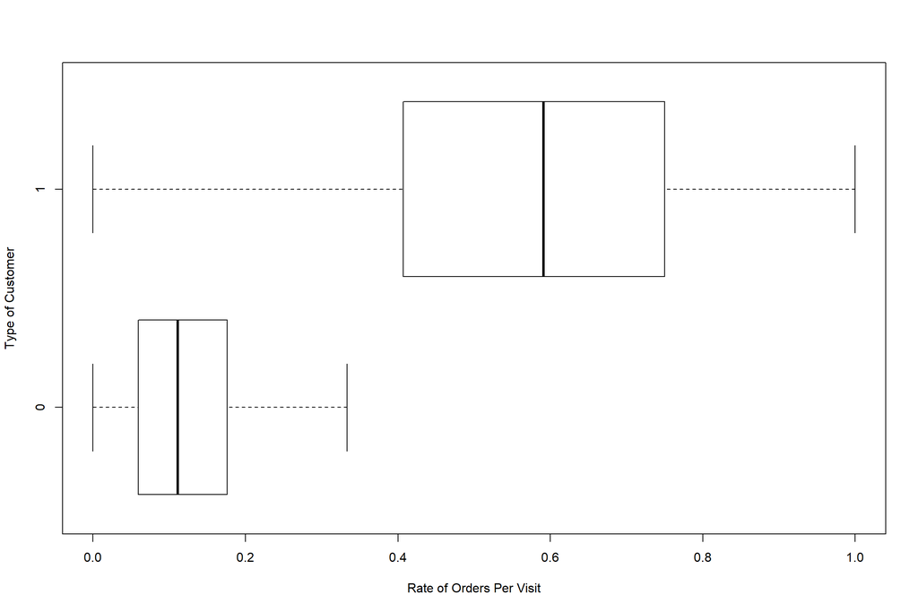

```r
boxplot(mydata$conversion_rate ~ mydata$new_customer, outline=FALSE, xlab = 'Rate of Orders Per Visit', ylab='Type of Customer', horizontal=TRUE)
```

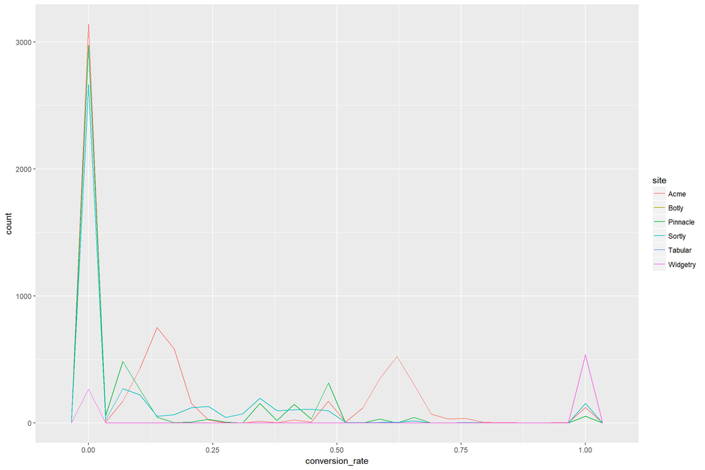

```r
ggplot(data=mydata, mapping = aes(x = conversion_rate)) +
  geom_freqpoly(mapping = aes(color = site))
```

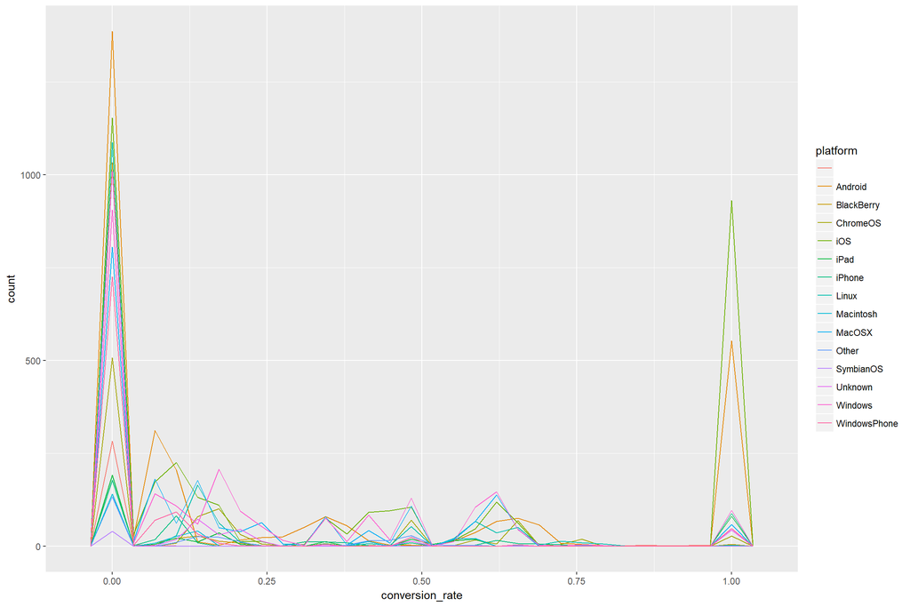

```r
ggplot(data=mydata, mapping = aes(x = conversion_rate)) +
  geom_freqpoly(mapping = aes(color = platform))
```

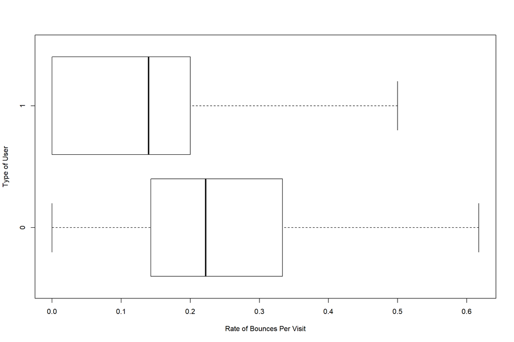

```r
boxplot(mydata$bounce_rate ~ mydata$new_customer, outline=FALSE, xlab = 'Rate of Bounces Per Visit', ylab='Type of User', horizontal = TRUE)
```

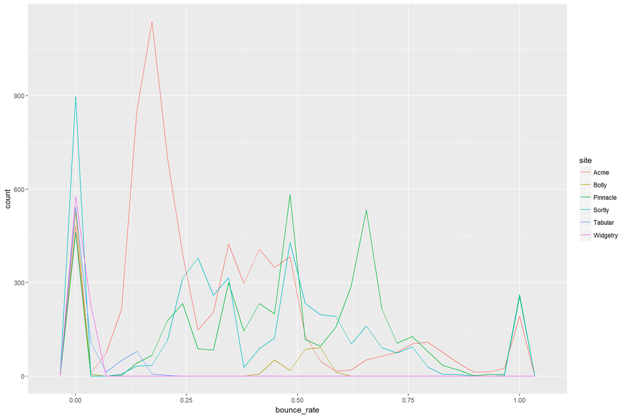

```r
ggplot(data=mydata, mapping = aes(x = bounce_rate)) +
  geom_freqpoly(mapping = aes(color = site))
```

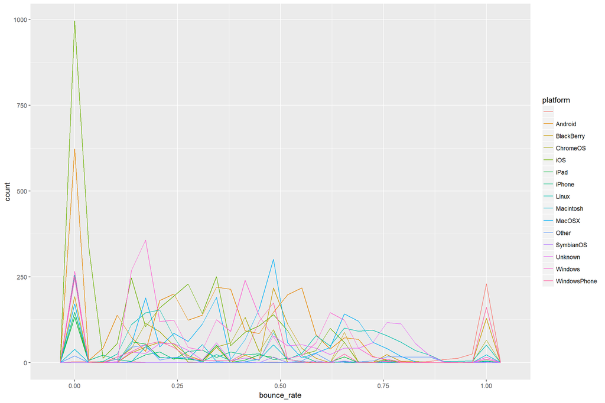

```r
ggplot(data=mydata, mapping = aes(x = bounce_rate)) +
  geom_freqpoly(mapping = aes(color = platform))
```

Distribution of the number of orders per type of user/customer as well as a scatterplot of the orders. The scatterplot can show us the relationships or correlation between each column and the orders.

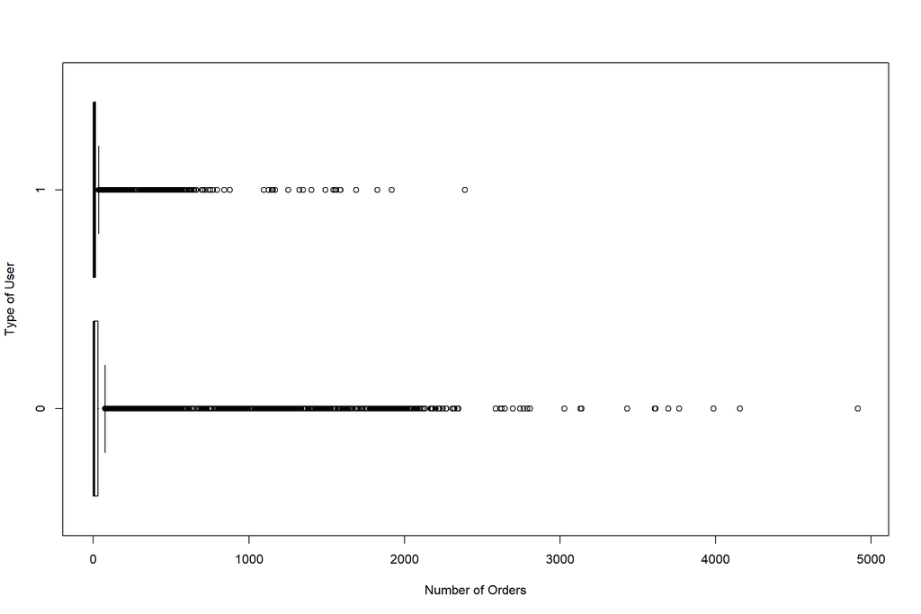

```r
boxplot(mydata$orders ~ mydata$new_customer, xlab = 'Number of Orders', ylab='Type of User', horizontal = TRUE)
```

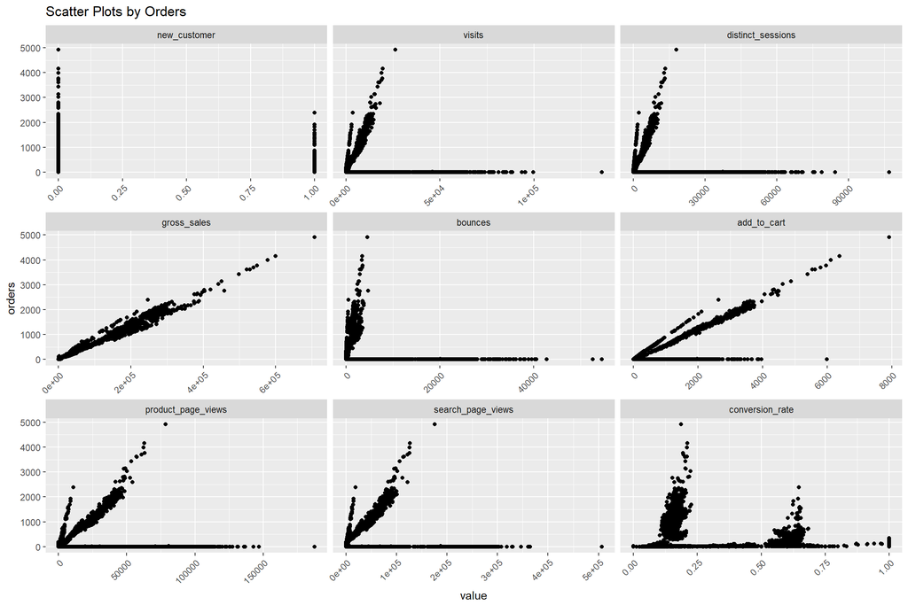

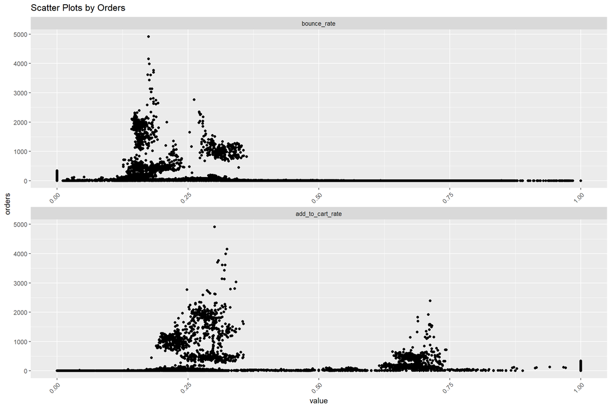

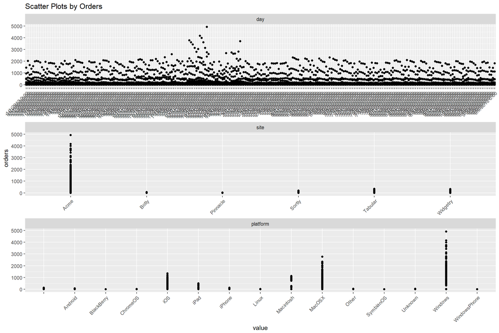

```r
plot_scatterplot(mydata, "orders", title = "Scatter Plots by Orders")
```

Here is a complete histogram of all continuous variables in the data set:

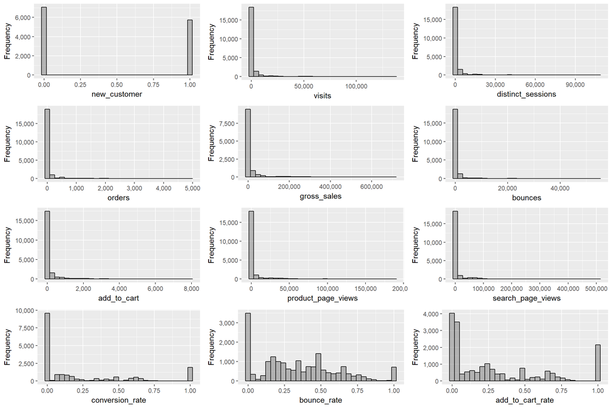

```r
plot_histogram(my_data)
```

It seems that most of the continuous data are right skewed with many missing values. Let’s take it a step further and look at the bivariate correlation of some variables with respect to the others. We will begin with the continuous variables.

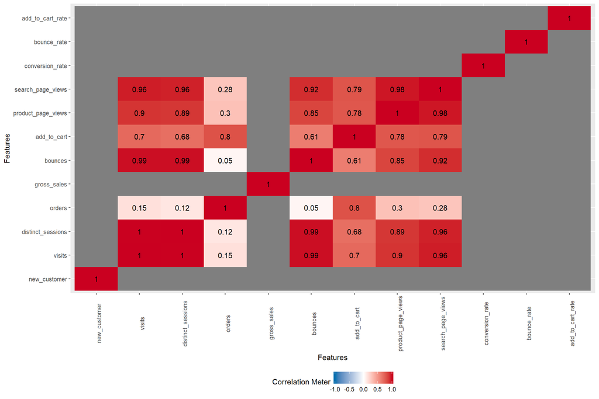

```r
plot_correlation(mydata, type = "c")
```

Now let’s look at the discrete variables.

```
## 1 features with more than 20 categories ignored!
## day: 268 categories
```

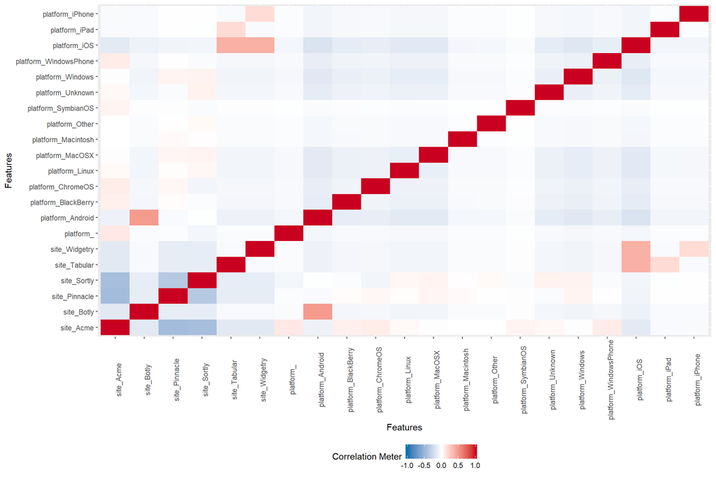

```r
plot_correlation(mydata, type = "d")
```

Using the plot above, Acme shows to have negative correlation to Sortly and Pinnacle, while there is a strong correlation between the use of Android platforms paired with the Botly site. We can also see that iOS users display a stronger correlation with the Widgetry and Tabular sites than with any other sites.